# 3: Logistic regression

```r
date()
```

```
## [1] "Tue Nov 22 02:18:00 2022"
```

Reading in the data that got wrangled before and summarizing the different variables:

```r
alc <- read.csv("data/alc.csv")

#Changing the name of the grade columns to be more descriptive
colnames(alc)[31] <- "Grade_1st"
colnames(alc)[32] <- "Grade_2nd"
colnames(alc)[33] <- "Grade_3rd"

# print out the variable names of the data set
colnames(alc)
```

```
##  [1] "school"     "sex"        "age"        "address"    "famsize"
##  [6] "Pstatus"    "Medu"       "Fedu"       "Mjob"       "Fjob"
## [11] "reason"     "guardian"   "traveltime" "studytime"  "schoolsup"
## [16] "famsup"     "activities" "nursery"    "higher"     "internet"
## [21] "romantic"   "famrel"     "freetime"   "goout"      "Dalc"
## [26] "Walc"       "health"     "failures"   "paid"       "absences"
## [31] "Grade_1st"  "Grade_2nd"  "Grade_3rd"  "alc_use"    "high_use"
```

This data frame is combined from 2 data sets of Student performance in secondary education mathematics and portugese of two Portuguese schools.The data sets and further explanations for individual attributes can be accessed [here](https://archive.ics.uci.edu/ml/datasets/Student+Performance). The data includes personal information from 370 students and answers to different aspects of their life and school success, as seen in the variable names above. Grades are from each school period (1st to 3rd). Only answers from students attended to both mathematics and portugese are used, and presented grades and other numerical information are mean values of answers given on the math and portugese classes (from the same student). In addition to the original data attributes, weekday and weekend (Dalc and Walc) alcohol consumption are combined into a single alc_use variable and a binary variable for high alcohol use is added. Alcohol use is considered high when mean alcohol use levels are above 2/5.

### The relationships between high/low alcohol consumption and some of the other variables in the data

First, lets compare the data of girls vs. boys and their alcohol consumption to school success (failures, mean grade, absences).

```r
# produce summary statistics by sex and alcohol (high/low) use
alc %>% group_by(sex, high_use) %>% summarise(count = n(), failures = mean(failures), mean_grade = mean(Grade_3rd), absences = mean(absences))
```

[output not shown]

```
## # A tibble: 4 × 6
## # Groups:   sex [2]
##   sex   high_use count failures mean_grade absences
##   <chr> <lgl>    <int>    <dbl>      <dbl>    <dbl>
## 1 F     FALSE      154    0.104       11.4     4.25
## 2 F     TRUE        41    0.293       11.8     6.85
## 3 M     FALSE      105    0.143       12.3     2.91
## 4 M     TRUE        70    0.386       10.3     6.1
```

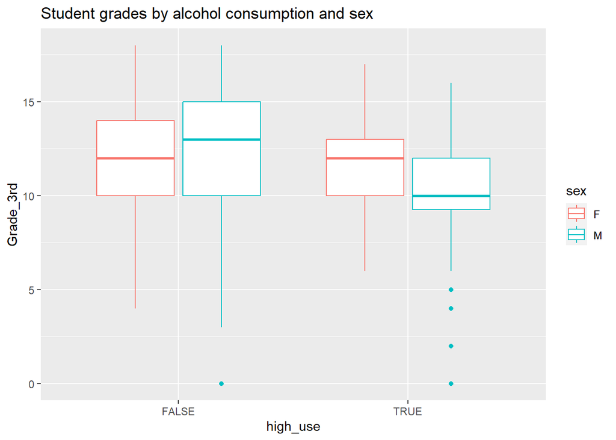

```r
# initialize a plot of high_use and Grade
g1 <- ggplot(alc, aes(x = high_use, y = Grade_3rd, col = sex))
# define the plot as a boxplot and draw it
g1 + geom_boxplot() + ggtitle("Student grades by alcohol consumption and sex")
```

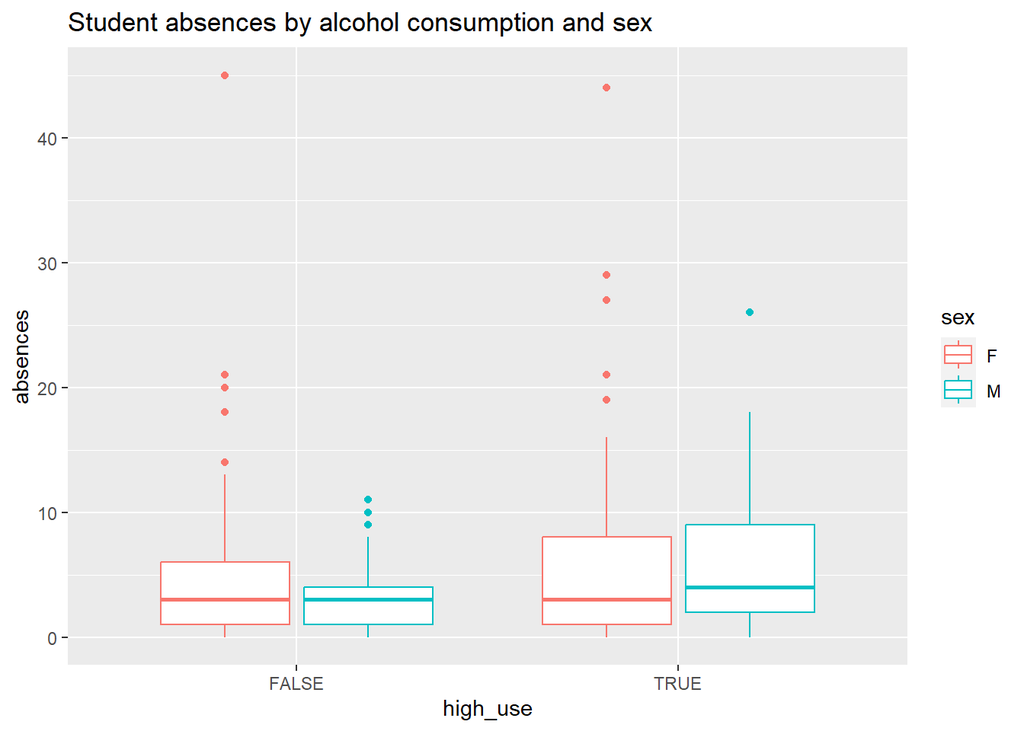

```r
# initialize a plot of high_use and absences
g2 <- ggplot(alc, aes(x = high_use, y = absences, col = sex))
# define the plot as a box plot and draw it
g2 + geom_boxplot() + ggtitle("Student absences by alcohol consumption and sex")
```

The majority of students are not heavy alcohol users across both sexes (259 vs. 111). The amounts of failures are higher among the heavy users, especially with male participants, and their mean grades were also the lowest. Interestingly for female participants the high alcohol use did not affect the mean grades by much, even though the females with high alcohol use have on average the most absences.

The *numbers* would suggest that although the females who used higher amounts of alcohol were absent more, their average grades were not affected by this as much as for the male participants. However the box plot shows the amount of outliers affecting the average numbers of absences, and it seems that most of high alcohol users regardless of gender would have similar amount of absences, but higher variation than low-alcohol users

Then, lets compare the data of girls vs. boys and their alcohol consumption to family relations and health.

```r
# produce summary statistics by sex and alcohol (high/low) use
alc %>% group_by(sex, high_use) %>% summarise(count = n(), family_relations = mean(famrel), health = mean(health), )
```

[output not shown]

```
## # A tibble: 4 × 5
## # Groups:   sex [2]
##   sex   high_use count family_relations health
##   <chr> <lgl>    <int>            <dbl>  <dbl>
## 1 F     FALSE      154             3.92   3.37
## 2 F     TRUE        41             3.73   3.39
## 3 M     FALSE      105             4.13   3.67
## 4 M     TRUE        70             3.79   3.93
```

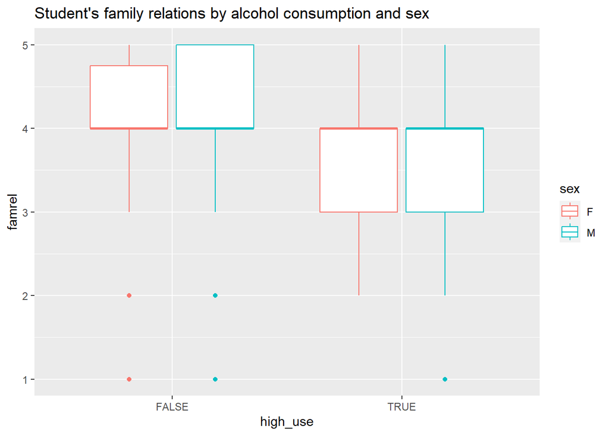

```r
# initialize a plot of high_use and absences
g3 <- ggplot(alc, aes(x = high_use, y = famrel, col = sex))
# define the plot as a box plot and draw it
g3 + geom_boxplot() + ggtitle("Student's family relations by alcohol consumption and sex")
```

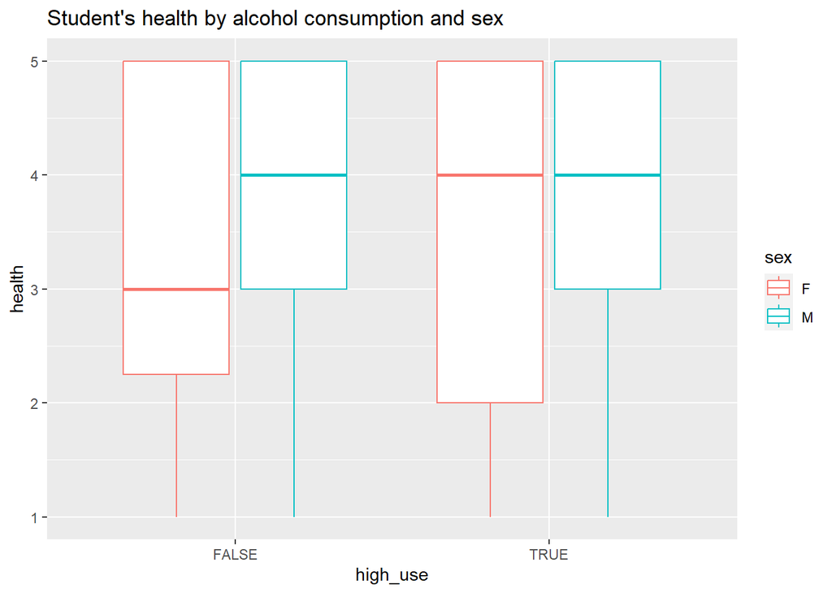

```r
# initialize a plot of high_use and absences
g4 <- ggplot(alc, aes(x = high_use, y = health, col = sex))
# define the plot as a box plot and draw it
g4 + geom_boxplot() + ggtitle("Student's health by alcohol consumption and sex")
```

Family relations seemed to be a little bit worse with high alcohol users, but very homogeneous across sexes. Surprisingly for reported health status, male students with high alcohol use would report on average best overall health, but for some reason this in not visible in the box plot. The health status had the highest variation of all variables

```r
# produce summary statistics by extra paid classes and alcohol (high/low) use
alc %>% group_by(paid, high_use) %>% summarise(count = n(), failures = mean(failures), mean_grade = mean(Grade_3rd))
```

```
## # A tibble: 4 × 5
## # Groups:   paid [2]
##   paid  high_use count failures mean_grade
##   <chr> <lgl>    <int>    <dbl>      <dbl>
## 1 no    FALSE      140   0.193        11.4
## 2 no    TRUE        56   0.5          10.8
## 3 yes   FALSE      119   0.0336       12.3
## 4 yes   TRUE        55   0.2          11.0
```

```r
# produce summary statistics by romantic relationship status and alcohol (high/low) use
alc %>% group_by(romantic, high_use) %>% summarise(count = n(), absences = mean(absences))
```

```
## # A tibble: 4 × 4
## # Groups:   romantic [2]
##   romantic high_use count absences
##   <chr>    <lgl>    <int>    <dbl>
## 1 no       FALSE      173     3.39
## 2 no       TRUE        78     5.77
## 3 yes      FALSE       86     4.35
## 4 yes      TRUE        33     7.82
```

Interesting side notes based on only average numbers:

- Taking extra paid classes would not significantly improve the mean grade for students with high alcohol use (even by a single grade), but it would decrease the failures by more than double
- More than double of high drinkers were not in a romantic relationship.
- Heavy drinkers with romantic relationships had the most absences

### Logistic regression to statistically explore the relationship between chosen variables and the binary high/low alcohol consumption

```r
# find the model with glm()
m <- glm(high_use ~ sex + failures + Grade_3rd + absences, data = alc, family = "binomial")

# compute odds ratios (OR)
OR <- coef(m) %>% exp

# compute confidence intervals (CI)
CI <- confint(m) %>% exp
# print out the odds ratios with their confidence intervals
cbind(OR, CI)
```

```
##                    OR      2.5 %    97.5 %
## (Intercept) 0.2497422 0.08880747 0.6760545
## sexM        2.7420380 1.69666006 4.4943946
## failures    1.6550376 1.08094265 2.5808643
## Grade_3rd   0.9543647 0.88291082 1.0311936
## absences    1.0948038 1.04844539 1.1486025
```

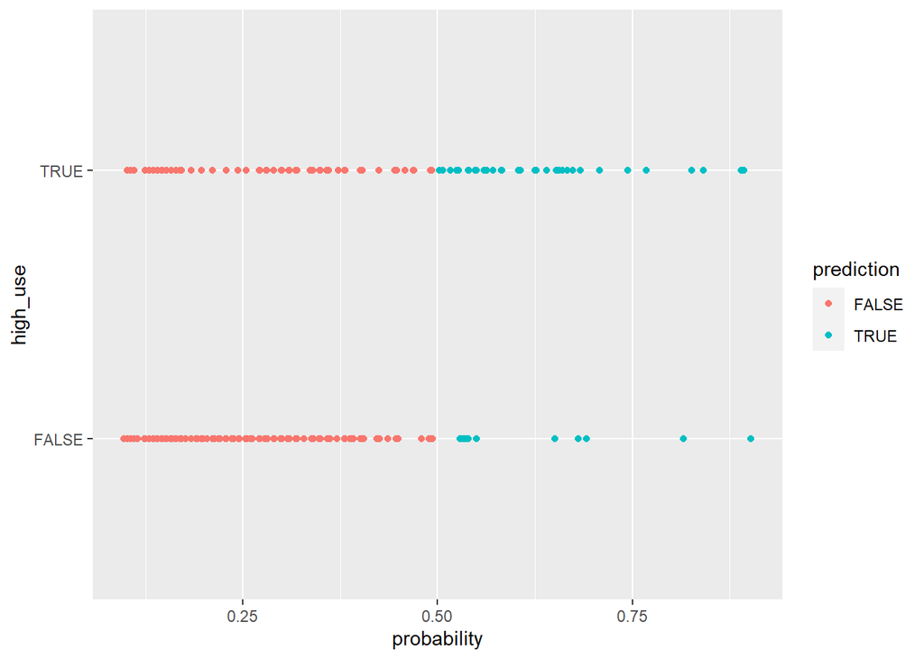

```r
# predict the probability of high_use and add the predicted probabilities to 'alc'
alc <- mutate(alc, probability = predict(m, type = "response"))

# use the probabilities to make a prediction of high_use
alc <- mutate(alc, prediction = probability > 0.5)

# initialize a plot of 'high_use' versus 'probability' in 'alc'
g <- ggplot(alc, aes(x = probability, y = high_use, col = prediction))
# define the geom as points and draw the plot
g + geom_point()
```

```r
# tabulate the target variable versus the predictions
table(high_use = alc$high_use, prediction = alc$prediction)
```

```
##         prediction
## high_use FALSE TRUE
##    FALSE   248   11
##    TRUE     77   34
```

```r
# tabulate the target variable versus the predictions to show total proportions
table(high_use = alc$high_use, prediction = alc$prediction) %>% prop.table() %>% addmargins()
```

```
##         prediction
## high_use      FALSE       TRUE        Sum
##    FALSE 0.67027027 0.02972973 0.70000000
##    TRUE  0.20810811 0.09189189 0.30000000
##    Sum   0.87837838 0.12162162 1.00000000
```